# Final EDA Notebook

# Bottom 10 Majors in terms of Median Salary

We also wanted to determine the lowest-earning majors to transparently inform students about their future financial outcomes. Compared to the highest-earning majors, the ten lowest-earning majors contain more variety in terms of major categories. Psychology and social work, along with humanities and liberal arts, comprise a more significant proportion of the lowest-earning majors. Students in these majors gain many transferable skills that can be applied to any occupation, which potentially explains why starting salaries can be lower than students who studied STEM. In addition, less technical jobs can involve more “caring” or “feminine” work, which society devalues because of cultural norms and structural obstacles.

```
## No summary function supplied, defaulting to `mean_se()`
```

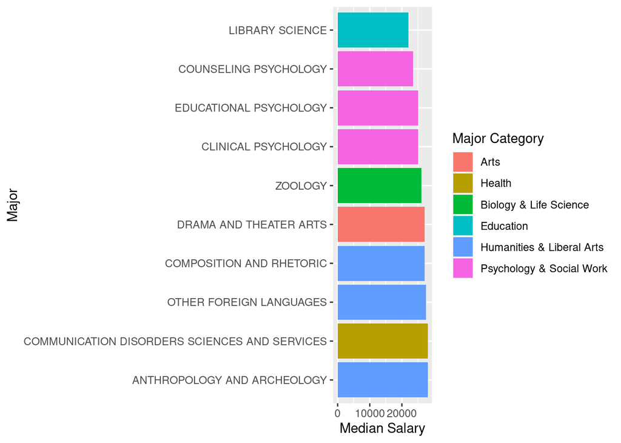

```r
bottom_10_salary <- recent_grads %>%
  select(Major, Median, Major_category, ShareWomen) %>%
  arrange(Median) %>%
  head(10)

ggplot(bottom_10_salary, aes(x=reorder(Major, -Median), y=Median, fill = Major_category))+
  geom_bar(stat="summary")+
  coord_flip()+
  labs(x="Major", y="Median Salary", fill = "Major Category")
```

# Visualizing Salary Distribution Amongst New Graduates

We created a box plot to visualize the trends in median salary and further examine the salary distribution between major categories. We found it interesting that majors such as law and public policy, business, and physical sciences have greater variation in terms of pay, as shown by the wider boxes. In contrast, majors like communications, education, and arts have a very narrow income range. Our findings should not discourage students from entering low-paying majors because, as shown below, variability exists within each industry.

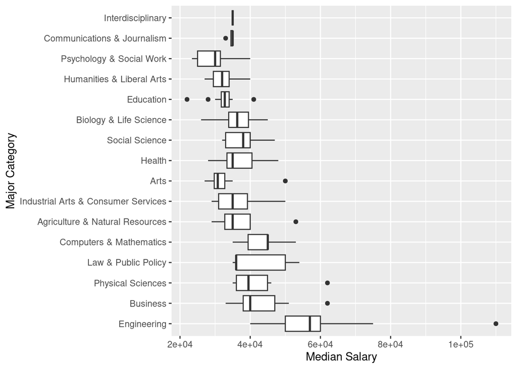

```r
ggplot(recent_grads, aes(x=Major_category, y=Median))+
  geom_boxplot()+
  xlab("Major Category")+
  ylab("Median Salary")+
  coord_flip()
```

# Calculating and Visualizing Employment Rate

To calculate the employment rate of each major category, we created a new variable in the dataset titled “Employment_rate.” We divided the count of employed graduates by the total count of graduates. We visualized the employment rate for each category using a box and whisker plot to understand the variability within the variable. Based on the box plot, education has the highest median employment rate, followed by agriculture and business majors. Interestingly, most major categories have median employment rates at or above 0.75(75%), except for Biology and Life Sciences. These results illuminated a surprising trend: graduates in less popular majors like agriculture and education appear to have better employment opportunities than those in more popular majors. Many reasons can explain this phenomenon, one being supply and demand economics. When the number of students pursuing a specific major exceeds the number of available job openings in a given industry, there will be a surplus of qualified graduates and a lower employment rate. Conversely, students pursuing unpopular or less prestigious majors encounter less competition in the job market and thus experience higher employment levels. We expect these trends to fluctuate based on market conditions and demand for specific industries.

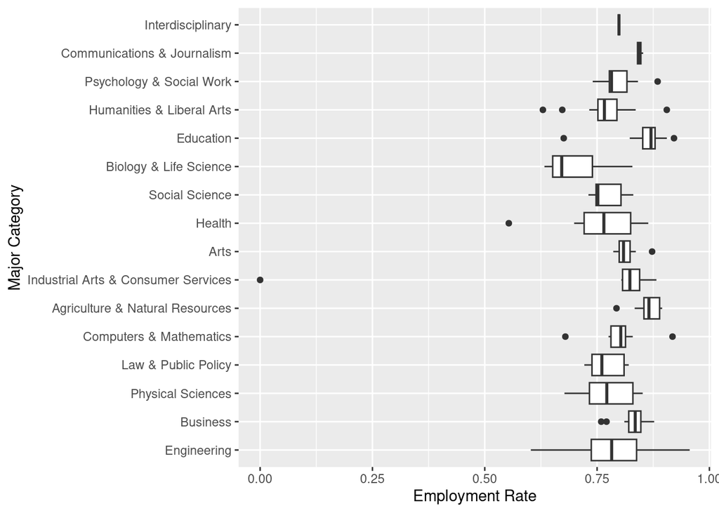

```r
recent_grads <- recent_grads %>%
  mutate(Employment_rate = Employed / Total)

ggplot(recent_grads, aes(x=Major_category, y=Employment_rate))+
  geom_boxplot()+
  coord_flip()+
  xlab("Major Category")+
  ylab("Employment Rate")
```

# Types of Employment: Full-time versus Part-time

Full-time versus part-time employment is an important consideration for evaluating job stability and quality. In this dataset, full-time workers work more than 35 hours a week, while part-time workers work fewer than 35 hours a week. Other differences between full-time and part-time employment include compensation, job security, and available benefits. Full-time employment is typically more stable and secure than part-time employment because of higher salaries and better benefits. Therefore, the type of employment matters when evaluating employment outcomes. To examine the proportion of full-time workers within the employed graduate population, we created a new variable titled “Prop_full_time” that divides the number of full-time workers by the total number of employed workers. We plotted the proportion of full-time workers by major category in the bar graph below. Based on the diagram below, business majors produce the largest proportion of full-time workers, followed by engineering, then computers and mathematics. On the other end of the spectrum, arts, humanities, and health majors have the lowest proportion of graduates working full-time. This result makes sense because industries are structured differently. Graduates in the arts and humanities experience more freelance employment opportunities, meaning they are more likely to sign project-based or part-time contracts. In contrast, graduates in the business or technology industry tend to find corporate roles at established firms or companies that hire more full-time workers.

```
## No summary function supplied, defaulting to `mean_se()`
```

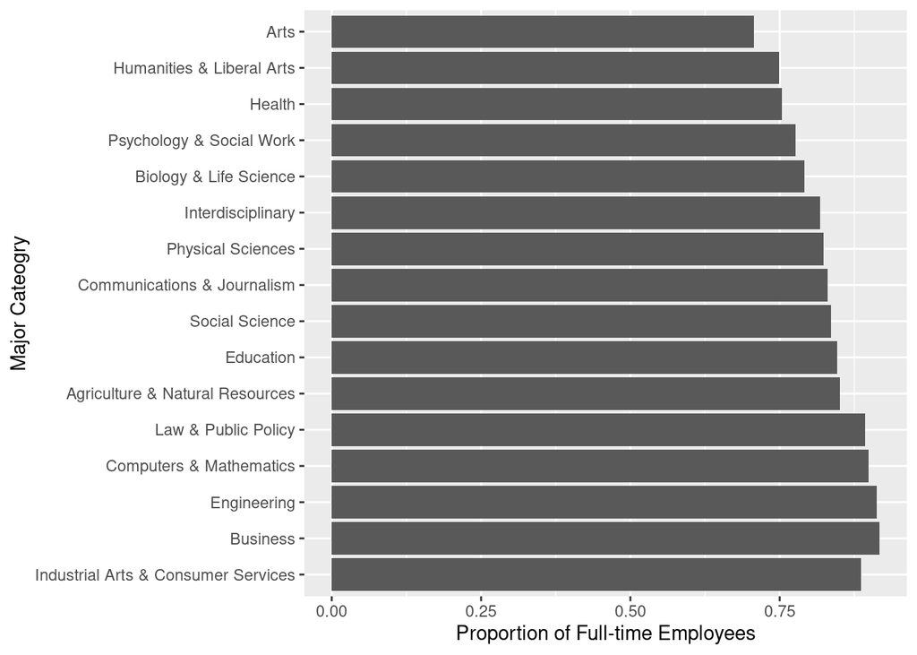

```r
recent_grads <- recent_grads %>%
  mutate(Prop_full_time = Full_time/Employed)

ggplot(recent_grads, aes(x= reorder(Major_category, -Prop_full_time), y=Prop_full_time))+
  geom_bar(stat="summary")+
  coord_flip()+
  xlab("Major Cateogry")+
  ylab("Proportion of Full-time Employees")
```

# Overview of Gender Distribution

Finally, we examined how majors vary in terms of gender composition. This bar graph uses the “ShareWomen” variable to illustrate the proportion of women in each major. Darker shades of blue represent low percentages of women while lighter shades of blue indicate a higher percentage. At a glance, we can see that majors like engineering and computers and mathematics have relatively low shares of women. In contrast, education, psychology and social work, and health correspond to greater percentages of women. These patterns reinforce widespread gender stereotypes in our society as STEM fields remain male-dominated while women disproportionately occupy fields that require emotional labor.

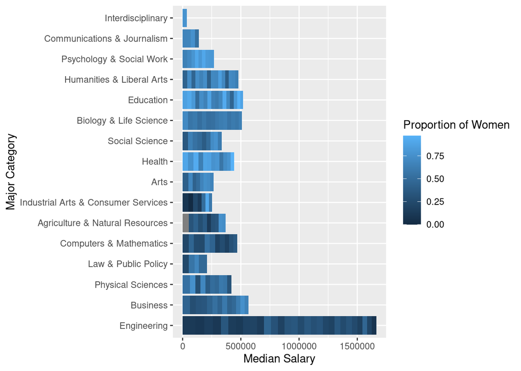

```r
ggplot(recent_grads, aes(x=Major_category, y= Median, fill=ShareWomen))+
  geom_bar(stat="identity")+
  coord_flip()+
  labs(x= "Major Category", y = "Median Salary", fill="Proportion of Women")
```

# Gender in High-Earning Majors

Using the list of top ten highest earning majors that we plotted earlier, we revised the graph to visualize the proportion of women that graduated with these degrees. Based on the scale shown below, the majority of these STEM-related majors are heavily male-dominated.

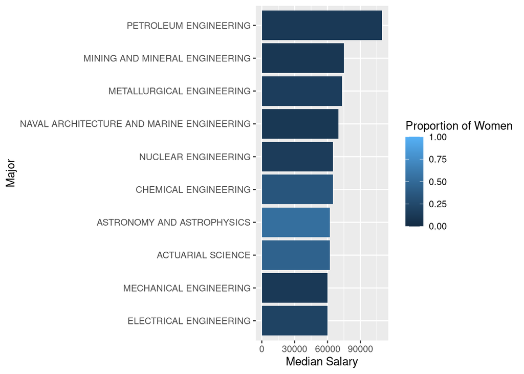

```r
top10_gender <- ggplot(top_10_salary, aes(x=reorder(Major, Median), y=Median, fill = ShareWomen))+
  geom_bar(stat="identity")+
  coord_flip()+
  labs(x="Major", y="Median Salary", fill = "Proportion of Women")+
  lims(fill=c(0,1))
print(top10_gender)
```